# week06_interactive_analysis_version2_collins

Mallory Collins

2026-04-24

```r
if (!require("MASS")) install.packages("MASS")
if (!require("plotly")) install.packages("plotly")
if (!require("crosstalk")) install.packages("crosstalk")


library(tidyverse)
library(MASS)
library(plotly)
library(crosstalk)

data("birthwt")

data <- birthwt %>%
  as_tibble() %>%
  mutate(
    low = factor(low, levels = c(0,1), labels = c("not_low","low")),
    smoke = factor(smoke, levels = c(0,1), labels = c("no","yes")),
    ht = factor(ht, levels = c(0,1), labels = c("no","yes")),
    ui = factor(ui, levels = c(0,1), labels = c("no","yes")),
    race = factor(race, levels = c(1,2,3), labels = c("white","black","other"))
  )
```

```r
# Basic structure
glimpse(data)
```

```
## Rows: 189
## Columns: 10
## $ low   <fct> not_low, not_low, not_low, not_low, not_low, not_low, not_low, n…
## $ age   <int> 19, 33, 20, 21, 18, 21, 22, 17, 29, 26, 19, 19, 22, 30, 18, 18, …
## $ lwt   <int> 182, 155, 105, 108, 107, 124, 118, 103, 123, 113, 95, 150, 95, 1…
## $ race  <fct> black, other, white, white, white, other, white, other, white, w…
## $ smoke <fct> no, no, yes, yes, yes, no, no, no, yes, yes, no, no, no, no, yes…
## $ ptl   <int> 0, 0, 0, 0, 0, 0, 0, 0, 0, 0, 0, 0, 0, 1, 0, 0, 0, 0, 0, 0, 0, 0…
## $ ht    <fct> no, no, no, no, no, no, no, no, no, no, no, no, yes, no, no, no,…
## $ ui    <fct> yes, no, no, yes, yes, no, no, no, no, no, no, no, no, yes, no, …
## $ ftv   <int> 0, 3, 1, 2, 0, 0, 1, 1, 1, 0, 0, 1, 0, 2, 0, 0, 0, 3, 0, 1, 2, 3…
## $ bwt   <int> 2523, 2551, 2557, 2594, 2600, 2622, 2637, 2637, 2663, 2665, 2722…
```

```r
# Dimensions
dim(data)
```

```
## [1] 189  10
```

```r
# Variable names
names(data)
```

```
##  [1] "low"   "age"   "lwt"   "race"  "smoke" "ptl"   "ht"    "ui"    "ftv"
## [10] "bwt"
```

```r
# Create a clean summary table
summary_table <- data %>%
  summarise(
    n = n(),
    mean_age = mean(age, na.rm = TRUE),
    mean_weight = mean(lwt, na.rm = TRUE),
    mean_birth_weight = mean(bwt, na.rm = TRUE)
  )

# Display nicely formatted table
knitr::kable(
  summary_table,
  caption = "Summary statistics for birth weight dataset",
  digits = 2
)
```

Summary statistics for birth weight dataset

| n | mean_age | mean_weight | mean_birth_weight |
| --- | --- | --- | --- |
| 189 | 23.24 | 129.81 | 2944.59 |

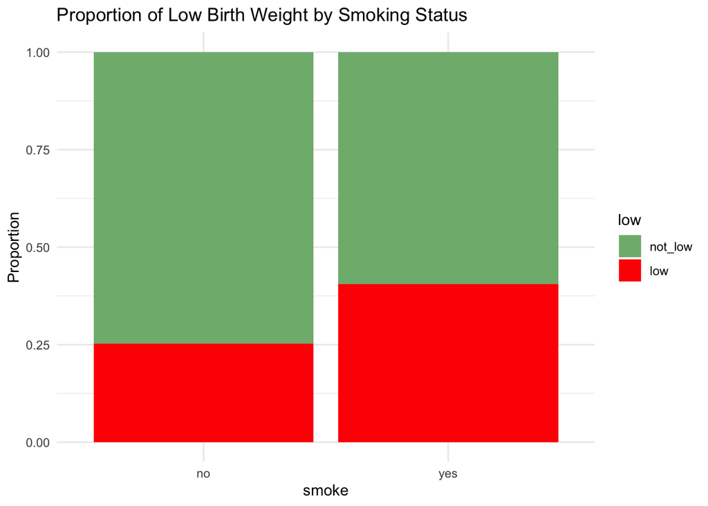

```r
smoke_plot <- ggplot(data, aes(x = smoke, fill = low)) +
  geom_bar(position = "fill") +
  scale_fill_manual(values = c("not_low" = "#7FB77E", "low" = "red")) +
  labs(
    title = "Proportion of Low Birth Weight by Smoking Status",
    y = "Proportion"
  ) +
  theme_minimal()

smoke_plot
```

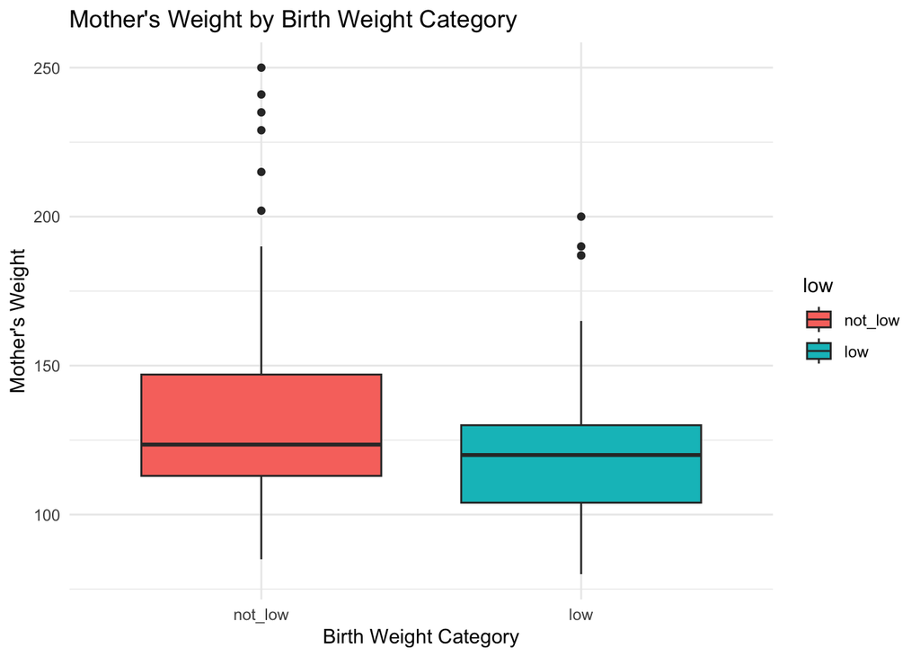

```r
weight_plot <- ggplot(data, aes(x = low, y = lwt, fill = low)) +
  geom_boxplot() +
  labs(
    title = "Mother's Weight by Birth Weight Category",
    x = "Birth Weight Category",
    y = "Mother's Weight"
  ) +
  theme_minimal()

weight_plot
```

```r
shared_data <- SharedData$new(data)

bscols(
  widths = c(3, 9),
  list(
    filter_select(
      id = "smoke_filter",
      label = "Smoking status",
      sharedData = shared_data,
      group = ~smoke
    ),
    filter_slider(
      id = "age_filter",
      label = "Mother's age",
      sharedData = shared_data,
      column = ~age
    )
  ),
  plot_ly(
    shared_data,
    x = ~lwt,
    y = ~bwt,
    color = ~low,
    type = "scatter",
    mode = "markers"
  )
)
```

Smoking status

Mother's age

[interactive chart not shown]

What happens when you change the filters? you can isolate different combinations of data depending on the mothers smoking status and age. Why might interactive plots be useful? You can compare data without making several graphs

Why is a linear model not appropriate here? because we are comparing the differences between two sets of data What type of response variable do we have? binary

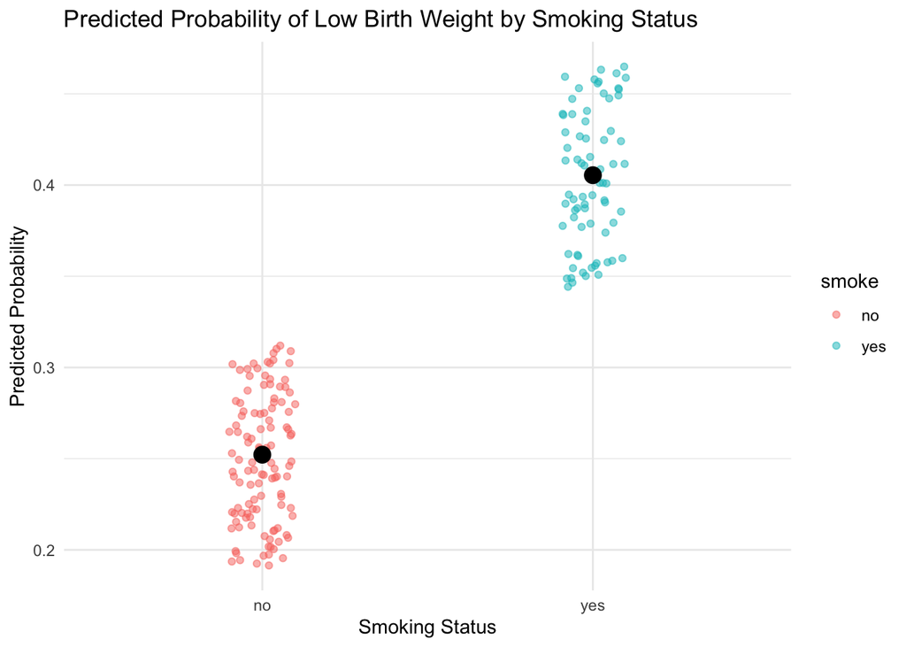

```r
# Fit model
model1 <- glm(low ~ smoke, data = data, family = binomial)

# Create predicted values
data$pred_prob <- predict(model1, type = "response")

# Plot
ggplot(data, aes(x = smoke, y = pred_prob, color = smoke)) +
  geom_jitter(width = 0.1, alpha = 0.5) +
  stat_summary(fun = mean, geom = "point", size = 4, color = "black") +
  labs(
    title = "Predicted Probability of Low Birth Weight by Smoking Status",
    y = "Predicted Probability",
    x = "Smoking Status"
  ) +
  theme_minimal()
```

```r
model2 <- glm(low ~ smoke + age + lwt + ht + ui, data = data, family = binomial)
summary(model2)
```

```
##
## Call:
## glm(formula = low ~ smoke + age + lwt + ht + ui, family = binomial,
##     data = data)
##
## Coefficients:
##              Estimate Std. Error z value Pr(>|z|)
## (Intercept)  1.399794   1.080407   1.296   0.1951
## smokeyes     0.647540   0.336650   1.923   0.0544 .
## age         -0.034073   0.033674  -1.012   0.3116
## lwt         -0.015447   0.006587  -2.345   0.0190 *
## htyes        1.893274   0.683392   2.770   0.0056 **
## uiyes        0.884607   0.444051   1.992   0.0464 *
## ---
## Signif. codes:  0 '***' 0.001 '**' 0.01 '*' 0.05 '.' 0.1 ' ' 1
##
## (Dispersion parameter for binomial family taken to be 1)
##
##     Null deviance: 234.67  on 188  degrees of freedom
## Residual deviance: 211.78  on 183  degrees of freedom
## AIC: 223.78
##
## Number of Fisher Scoring iterations: 4
```

The smoking of the mother does not have a significant effect on low birthweight. This result is seen by a p value greater than 0.05 by sorting binary data, if a newborn had low birthweught or not and if the mother smokes. Therefore we accept the null hypothesis that smking does not have a significatn effect on birth weight.

What biological or health factors might explain these results? smoking could also lead to hypeertension and low weight of the mother, other variables which had a lower p value than smoking alone. What are limitations of this dataset? Geographical regions, income, and acess to healcare are also factors not reported that may have an effect on birth weight. How does this compare to your expectations? I was surprised that smoking alone is not associated significantly with low birth weight, but it makes sense that low birthweight is the outcome of an accumulation of variables.